# Loan Applications

- Introduction
- Data Wrangling
- Univariate Exploration
- Bivariate Exploration
- Exploratory Data Analysis - Conclusions

## Introduction

The dataset I will investigate (source: Kaggle https://www.kaggle.com/gauravduttakiit/loan-defaulter) contains information about more than 300,000 loan applications. The goal of my analysis is to determine which borrowers' characteristics are mostly associated with delays in paying back the amount lent.

```python
import numpy as np
import pandas as pd
import matplotlib.pyplot as plt
from matplotlib.ticker import PercentFormatter
import seaborn as sns
import scipy
%matplotlib inline
%config InlineBackend.figure_format = 'retina'
plt.rcParams['figure.dpi']= 200
plt.rcParams['savefig.dpi'] = 200
#sns.set(rc={"figure.dpi":200, 'savefig.dpi':200})
#sns.set_context('notebook')
#sns.set_style("ticks")
```

```python
#The csv with the data can be found at the source mentioned above
df=pd.read_csv('application_data.csv')
```

## Data Wrangling

Check the number of rows and columns of the dataset.

```python
df.shape
```

```
(307511, 122)
```

The dataset has 122 features. I will keep only a few of them, which I think are the most relevant for the analysis. A complete list of all the features can be found here: https://www.kaggle.com/gauravduttakiit/loan-defaulter?select=columns_description.csv

```python
my_columns = ['SK_ID_CURR', 'TARGET', 'CODE_GENDER', 'FLAG_OWN_CAR', 'FLAG_OWN_REALTY', 'CNT_CHILDREN', 'AMT_INCOME_TOTAL',
              'AMT_CREDIT', 'NAME_EDUCATION_TYPE', 'NAME_FAMILY_STATUS', 'DAYS_BIRTH', 'CNT_FAM_MEMBERS']
```

```python
df=df[my_columns]
```

```python
df.head()
```

|  | SK_ID_CURR | TARGET | CODE_GENDER | FLAG_OWN_CAR | FLAG_OWN_REALTY | CNT_CHILDREN | AMT_INCOME_TOTAL | AMT_CREDIT | NAME_EDUCATION_TYPE | NAME_FAMILY_STATUS | DAYS_BIRTH | CNT_FAM_MEMBERS |
| --- | --- | --- | --- | --- | --- | --- | --- | --- | --- | --- | --- | --- |
| 0 | 100002 | 1 | M | N | Y | 0 | 202500.0 | 406597.5 | Secondary / secondary special | Single / not married | -9461 | 1.0 |
| 1 | 100003 | 0 | F | N | N | 0 | 270000.0 | 1293502.5 | Higher education | Married | -16765 | 2.0 |
| 2 | 100004 | 0 | M | Y | Y | 0 | 67500.0 | 135000.0 | Secondary / secondary special | Single / not married | -19046 | 1.0 |
| 3 | 100006 | 0 | F | N | Y | 0 | 135000.0 | 312682.5 | Secondary / secondary special | Civil marriage | -19005 | 2.0 |
| 4 | 100007 | 0 | M | N | Y | 0 | 121500.0 | 513000.0 | Secondary / secondary special | Single / not married | -19932 | 1.0 |

Rename column headers in a more descriptive way.

```python
df = df.rename(columns={'SK_ID_CURR': 'id', 'TARGET': 'late_payments', 'CODE_GENDER': 'gender', 'FLAG_OWN_CAR': 'own_car',
                        'FLAG_OWN_REALTY': 'own_house', 'CNT_CHILDREN': 'n_children', 'AMT_INCOME_TOTAL': 'income',
                        'AMT_CREDIT': 'loan_amount', 'NAME_EDUCATION_TYPE': 'education', 'NAME_FAMILY_STATUS': 'family_status',
                        'DAYS_BIRTH': 'age', 'CNT_FAM_MEMBERS': 'family_members'})
```

Concise summary of the dataframe.

```python
df.info()
```

```
<class 'pandas.core.frame.DataFrame'>
RangeIndex: 307511 entries, 0 to 307510
Data columns (total 12 columns):
id                307511 non-null int64
late_payments     307511 non-null int64
gender            307511 non-null object
own_car           307511 non-null object
own_house         307511 non-null object
n_children        307511 non-null int64
income            307511 non-null float64
loan_amount       307511 non-null float64
education         307511 non-null object
family_status     307511 non-null object
age               307511 non-null int64
family_members    307509 non-null float64
dtypes: float64(3), int64(4), object(5)
memory usage: 28.2+ MB
```

Brief description of the columns used in this analysis:

- id: loan ID
- late_payments: 1 if client with payment difficulties
- gender: gender of the client
- own_car: Y if client owns a car
- own_house: Y if client owns a house or flat
- n_children: number of children the client has
- income: income of the client in USD
- loan_amount: amount of the loan in USD
- education: highest level of education the client achieved
- family_status: family status of the client (e.g. single, married)
- age: age at the time of application
- family_members: number of family members the client has

Set the column 'id' as the new index.

```python
df.set_index('id', inplace=True)
```

```python
df.head()
```

| id | late_payments | gender | own_car | own_house | n_children | income | loan_amount | education | family_status | age | family_members |
| --- | --- | --- | --- | --- | --- | --- | --- | --- | --- | --- | --- |
| 100002 | 1 | M | N | Y | 0 | 202500.0 | 406597.5 | Secondary / secondary special | Single / not married | -9461 | 1.0 |
| 100003 | 0 | F | N | N | 0 | 270000.0 | 1293502.5 | Higher education | Married | -16765 | 2.0 |
| 100004 | 0 | M | Y | Y | 0 | 67500.0 | 135000.0 | Secondary / secondary special | Single / not married | -19046 | 1.0 |
| 100006 | 0 | F | N | Y | 0 | 135000.0 | 312682.5 | Secondary / secondary special | Civil marriage | -19005 | 2.0 |
| 100007 | 0 | M | N | Y | 0 | 121500.0 | 513000.0 | Secondary / secondary special | Single / not married | -19932 | 1.0 |

Create a copy of the dataframe before proceeding with the cleaning operations.

```python
df_unclean = df.copy()
```

Check if there are duplicate loan IDs.

```python
sum(df.index.duplicated())
```

```
0
```

Check if there are duplicate values in all the other characteristics of borrowers.

```python
sum(df.duplicated())
```

```
57
```

I find it very unlikely that there are borrowers with the exact same characteristics in all the features: these are probably borrowers that were entered more than once, thus I will drop them.

```python
df = df.drop_duplicates()
```

```python
sum(df.duplicated())
```

```
0
```

```python
#Must return True
df_unclean.shape[0]-sum(df_unclean.duplicated())==df.shape[0]
```

```
True
```

As shown above, there are two missing values in the column 'family_members'.

```python
df.loc[df['family_members'].isna()]
```

| id | late_payments | gender | own_car | own_house | n_children | income | loan_amount | education | family_status | age | family_members |
| --- | --- | --- | --- | --- | --- | --- | --- | --- | --- | --- | --- |
| 148605 | 0 | M | N | Y | 0 | 450000.0 | 675000.0 | Lower secondary | Unknown | -12396 | NaN |
| 317181 | 0 | F | N | Y | 0 | 202500.0 | 585000.0 | Higher education | Unknown | -12844 | NaN |

Column 'family_members' is missing and the 'family_status' is unknown. I will drop these observations as well.

```python
df.dropna(subset=['family_members'], axis=0, inplace=True)
```

```python
#Return 0 if there isn't any null value in the whole dataframe
df.isnull().sum().sum()
```

```
0
```

Check unique values in all the categorical features.

```python
for col in ['late_payments', 'gender', 'own_car', 'own_house', 'education', 'family_status']:
    print(df[col].value_counts(), '\n')
```

```
0    282628
1     24824
Name: late_payments, dtype: int64

F      202407
M      105041
XNA         4
Name: gender, dtype: int64

N    202881
Y    104571
Name: own_car, dtype: int64

Y    213259
N     94193
Name: own_house, dtype: int64

Secondary / secondary special    218345
Higher education                  74853
Incomplete higher                 10275
Lower secondary                    3815
Academic degree                     164
Name: education, dtype: int64

Married                 196395
Single / not married     45433
Civil marriage           29771
Separated                19770
Widow                    16083
Name: family_status, dtype: int64
```

I noticed there are 4 observations with "XNA" as gender: since they are just a few I will drop them.

```python
df.drop(df.loc[df['gender']=='XNA'].index, inplace=True)
```

```python
df['gender'].value_counts()
```

```
F    202407
M    105041
Name: gender, dtype: int64
```

Rename one of the categories of "education".

```python
df['education'].replace('Secondary / secondary special', 'Secondary education', inplace=True)
```

There are only a few borrowers whose "education" level is "Academic degree". Moreover, "Academic degree" can be classified as Higher education, therefore I will just include those values under that category.

```python
df['education'].replace('Academic degree', 'Higher education', inplace=True)
```

```python
df['education'].unique()
```

```
array(['Secondary education', 'Higher education', 'Incomplete higher',
       'Lower secondary'], dtype=object)
```

Set the proper order.

```python
df['education'] = pd.Categorical(df['education'], categories=['Lower secondary','Secondary education','Incomplete higher',
                                                              'Higher education'], ordered=True)
```

Show for each category of "family_status" the number of each category of "family_members".

```python
df.groupby('family_status')['family_members'].value_counts()
```

```
family_status         family_members
Civil marriage        2.0                20943
                      3.0                 6587
                      4.0                 1936
                      5.0                  262
                      6.0                   33
                      7.0                    5
                      8.0                    2
                      9.0                    1
                      11.0                   1
Married               2.0               126541
                      3.0                43692
                      4.0                22494
                      5.0                 3190
                      6.0                  370
                      7.0                   74
                      8.0                   17
                      9.0                    5
                      10.0                   2
                      12.0                   2
                      14.0                   2
                      16.0                   2
                      13.0                   1
Separated             1.0                14132
                      2.0                 4389
                      3.0                 1111
                      4.0                  122
                      5.0                   12
                      6.0                    2
                      7.0                    1
                      15.0                   1
Single / not married  1.0                38799
                      2.0                 5578
                      3.0                  958
                      4.0                   85
                      5.0                    9
                      20.0                   2
                      6.0                    1
                      10.0                   1
Widow                 1.0                14900
                      2.0                  868
                      3.0                  248
                      4.0                   58
                      5.0                    5
                      6.0                    2
                      7.0                    1
                      8.0                    1
Name: family_members, dtype: int64
```

As expected, the large majority of married people have two family members, whereas the large majority of singles or widows have one. The column "family_members" is more informative than "family_status", so I will just drop the latter.

```python
df.drop(['family_status'], axis=1, inplace=True)
```

Compute the difference between "family_members" and "n_children", in order to obtain the number of adults in each family.

```python
df['n_adults']=df['family_members']-df['n_children']
```

```python
df['n_adults']=df['n_adults'].astype(int)
```

```python
df['n_adults'].value_counts()
```

```
2    226162
1     81286
Name: n_adults, dtype: int64
```

Drop column "family_members" as won't be needed anymore.

```python
df.drop(['family_members'], axis=1, inplace=True)
```

Transform "age" from number of days to number of years.

```python
df['age']=round(df['age']/-365).astype(int)
```

Convert "income" and "loan_amount" from USD to USD/000.

```python
df['income']=df['income']/1000
df['loan_amount']=df['loan_amount']/1000
```

Rename the categories of the variables "gender", "own_car", "own_house" in a more descriptive way.

```python
df.replace({'gender' : { 'M' : 'Male', 'F' : 'Female'}}, inplace=True)
df.replace({'own_car' : { 'N' : 'No', 'Y' : 'Yes'}}, inplace=True)
df.replace({'own_house' : { 'N' : 'No', 'Y' : 'Yes'}}, inplace=True)
```

##### Random Undersampling

As noticed earlier, the main variable of interest "late_payments" is highly imbalanced, as there is a severe skew in its distribution.

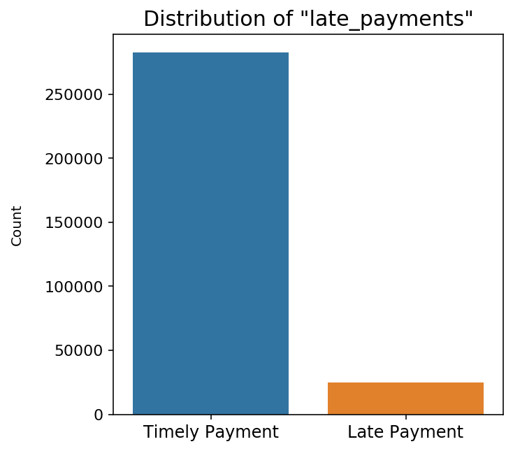

```python
plt.figure(figsize=(5,5))
ax = sns.countplot(data=df, x='late_payments')
ax.set_xticklabels(['Timely Payment', 'Late Payment'])
plt.title('Distribution of "late_payments"', fontsize=15)
plt.ylabel('Count', labelpad=15)
plt.xlabel('')
plt.yticks(fontsize=11)
plt.xticks(fontsize=12)
plt.show()
```

This bias would affect the clarity of my visualizations (as there would be too many values of one category) and the quality of the results of many machine learning algorithms, leading some of them to ignore the minority class entirely. One approach to address this problem is random undersampling, in which observations from the majority class are removed at random until a more balanced distribution is reached.

Therefore I will randomly pick a number of observations from the majority class that is equal to the number of observations in the minority class and remove all the others.

```python
df_late=df.loc[df['late_payments']==1]
n_late=df_late.shape[0] #Get the number of observations with 1 as timely_payments
df_timely=df.loc[df['late_payments']==0].sample(n_late, random_state=42) #Use a fixed random_state for reproducibility
```

```python
df = pd.concat([df_timely, df_late])
```

Visualize the dataframe after the wrangling phase.

```python
df.sample(10)
```

| id | late_payments | gender | own_car | own_house | n_children | income | loan_amount | education | age | n_adults |
| --- | --- | --- | --- | --- | --- | --- | --- | --- | --- | --- |
| 455443 | 1 | Male | No | Yes | 2 | 202.5 | 247.2750 | Secondary education | 31 | 2 |
| 134249 | 0 | Female | Yes | Yes | 1 | 90.0 | 225.0000 | Higher education | 32 | 2 |
| 395091 | 1 | Female | No | Yes | 0 | 81.0 | 148.3650 | Secondary education | 34 | 2 |
| 451190 | 0 | Female | No | Yes | 0 | 126.0 | 497.5200 | Higher education | 60 | 2 |
| 159962 | 1 | Male | No | No | 1 | 112.5 | 735.0525 | Secondary education | 40 | 2 |
| 194362 | 1 | Male | Yes | Yes | 0 | 99.0 | 942.3000 | Secondary education | 38 | 2 |
| 284303 | 0 | Female | Yes | Yes | 1 | 126.0 | 708.9390 | Higher education | 46 | 2 |
| 205112 | 1 | Male | No | Yes | 0 | 157.5 | 450.0000 | Secondary education | 24 | 2 |
| 268216 | 0 | Male | Yes | Yes | 1 | 202.5 | 405.0000 | Higher education | 38 | 2 |
| 226741 | 1 | Male | No | Yes | 0 | 180.0 | 331.8345 | Secondary education | 32 | 2 |

```python
df.info()
```

```
<class 'pandas.core.frame.DataFrame'>
Int64Index: 49648 entries, 336645 to 456254
Data columns (total 10 columns):
late_payments    49648 non-null int64
gender           49648 non-null object
own_car          49648 non-null object
own_house        49648 non-null object
n_children       49648 non-null int64
income           49648 non-null float64
loan_amount      49648 non-null float64
education        49648 non-null category
age              49648 non-null int32
n_adults         49648 non-null int32
dtypes: category(1), float64(2), int32(2), int64(2), object(3)
memory usage: 3.5+ MB
```

```python
df.describe()
```

|  | late_payments | n_children | income | loan_amount | age | n_adults |
| --- | --- | --- | --- | --- | --- | --- |
| count | 49648.000000 | 49648.000000 | 49648.000000 | 49648.000000 | 49648.000000 | 49648.000000 |
| mean | 0.500000 | 0.437017 | 167.297285 | 579.874577 | 42.517745 | 1.727099 |
| std | 0.500005 | 0.735500 | 532.387426 | 377.290686 | 11.864110 | 0.445455 |
| min | 0.000000 | 0.000000 | 25.650000 | 45.000000 | 21.000000 | 1.000000 |
| 25% | 0.000000 | 0.000000 | 112.500000 | 276.880500 | 33.000000 | 1.000000 |
| 50% | 0.500000 | 0.000000 | 144.000000 | 508.495500 | 41.000000 | 2.000000 |
| 75% | 1.000000 | 1.000000 | 202.500000 | 781.920000 | 52.000000 | 2.000000 |
| max | 1.000000 | 11.000000 | 117000.000000 | 4027.680000 | 69.000000 | 2.000000 |

From this summary I already noticed some values that will require further investigation in the next phase, such as the maximum amount of children (11) and the maximum value for income (117 million dollars).

### Quick Summary (Data Wrangling)

##### Structure of the dataset:

Originally the dataset had 307,511 rows and 122 columns: out of these I immediately selected only the columns that I think are the most relevant for the analysis. After the wrangling phase the resulting dataset has 49,648 rows and 10 columns.

##### Target variable:

The main feature of interest in the dataset is "late_payments", a categorical variable that can assume either 1 if the client had payment difficulties (i.e. he/she made a late payment on at least one of the first installments of the loan), or 0 in case he/she did not.

##### Other features:

I believe all the remaining features might be important in explaining the behavior of my target variable. In particular, I think the most important one is income. Higher income values are likely to be associated with less payment difficulties and vice versa.

## Univariate Exploration

In this section I will investigate the univariate distribution of each individual variable. Let's start with the target variable "late_payments".

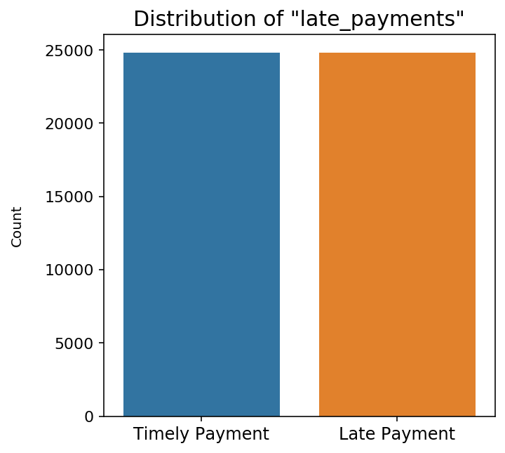

```python
plt.figure(figsize=(5,5))
ax = sns.countplot(data=df, x='late_payments')
ax.set_xticklabels(['Timely Payment', 'Late Payment'])
plt.title('Distribution of "late_payments"', fontsize=15)
plt.ylabel('Count', labelpad=15)
plt.xlabel('')
plt.yticks(fontsize=11)
plt.xticks(fontsize=12)
plt.show()
```

After I implemented the random undersampling the two categories of "late_payments" have the same number of observations. In the bivariate exploration I will investigate its relationship with all the other variables to determine which are associated the most with late payments.

Check univariate distribution of "gender", "own_car" and "own_house".

```python
#Define a function to create univariate bar charts
def make_bar(column):
    plt.figure(figsize=(5, 5))
    ax = sns.countplot(data=df, x=column, color='C0')
    plt.title('Distribution of "'+column+'"', fontsize=15)
    plt.ylabel('Count', labelpad=15)
    plt.xlabel('')
    plt.yticks(fontsize=11)
    plt.xticks(fontsize=12)
    plt.show()
```

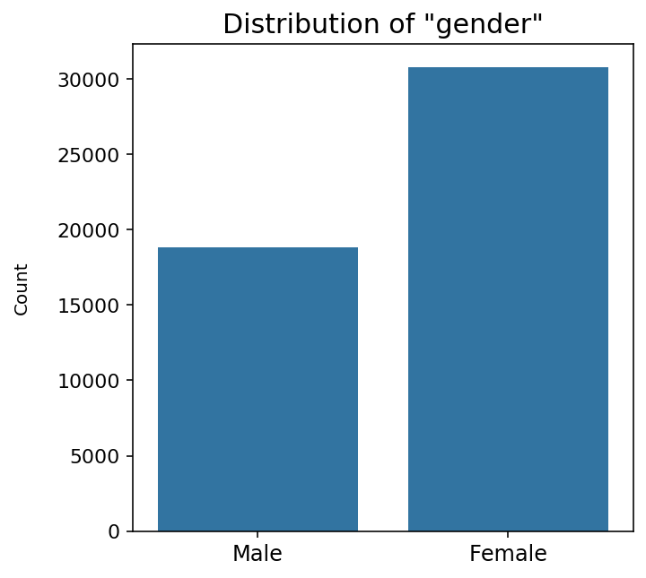

```python
make_bar('gender')
```

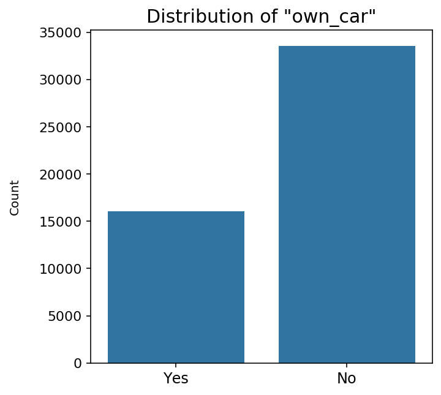

```python
make_bar('own_car')
```

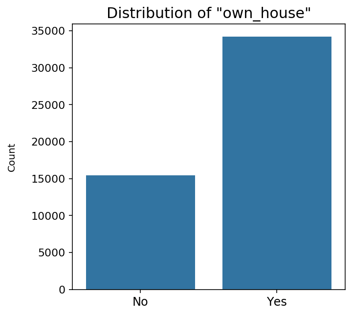

```python
make_bar('own_house')
```

The majority of borrowers are female, do not own a car but own a house. This is an interesting finding, as apparently the main purpose of the loan is to buy a car rather than a house.  
In the bivariate exploration I will check the relationships of "own_car" and "own_house" with "loan_amount": my expectation is that people who do not own a car borrowed a lower amount, whereas people who do not own a house borrowed a higher amount.

Check univariate distribution of "n_adults" and "n_children".

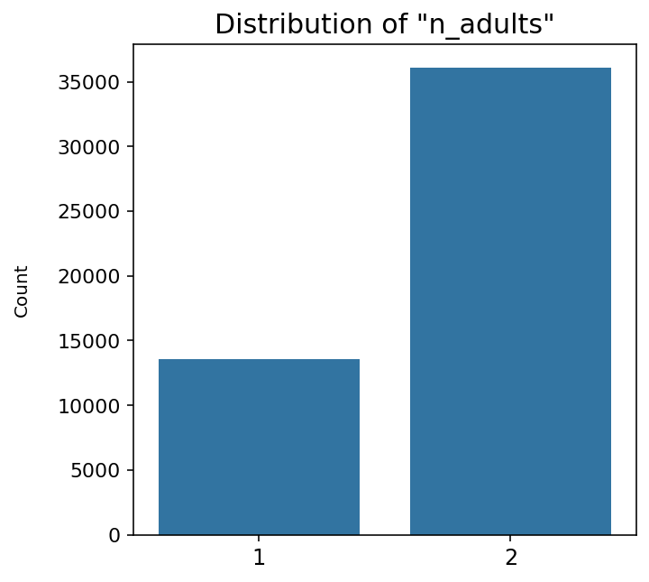

```python
make_bar('n_adults')
```

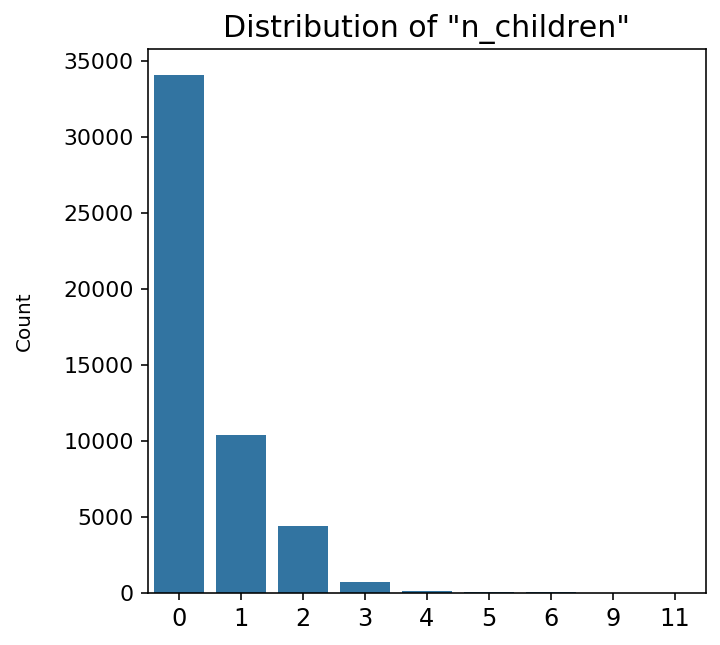

```python
make_bar('n_children')
```

There is a very limited amount of borrowers with more than 3 children so that they are not even shown in the above chart.

```python
df['n_children'].value_counts()
```

```
0     34091
1     10353
2      4418
3       681
4        83
5        10
6         9
9         2
11        1
Name: n_children, dtype: int64
```

To address these outliers I will just replace their values with the highest instance I will be keeping (which is 3) assuming it is the most similar, in order to avoid losing the information by dropping these observations.

```python
df['n_children'] = np.where(df['n_children']>3, 3, df['n_children'])
```

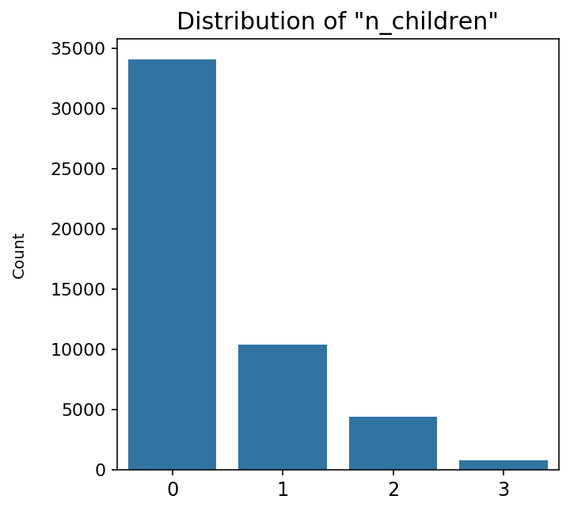

```python
make_bar('n_children')
```

The majority of borrowers live with another adult and have no children. My assumption is that people living with another adult tend to be more punctual while making the payments, because it is likely that there are two people contributing to the family income. On the other hand, a higher number of children means more expenses, thus I assume that these borrowers may have more financial difficulties and be late in repaying the amount back.

Check univariate distribution of "age" and "education".

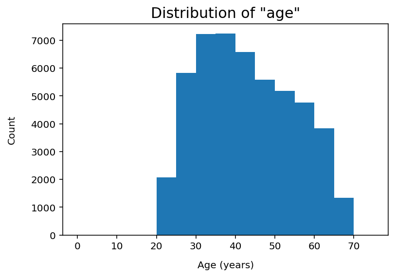

```python
bins = np.arange(0, df['age'].max()+10, 5)
plt.hist(data = df, x = 'age', bins=bins)
plt.title('Distribution of "age"', fontsize=15)
plt.ylabel('Count', labelpad=15)
plt.xlabel('Age (years)', labelpad=10)
plt.show()
```

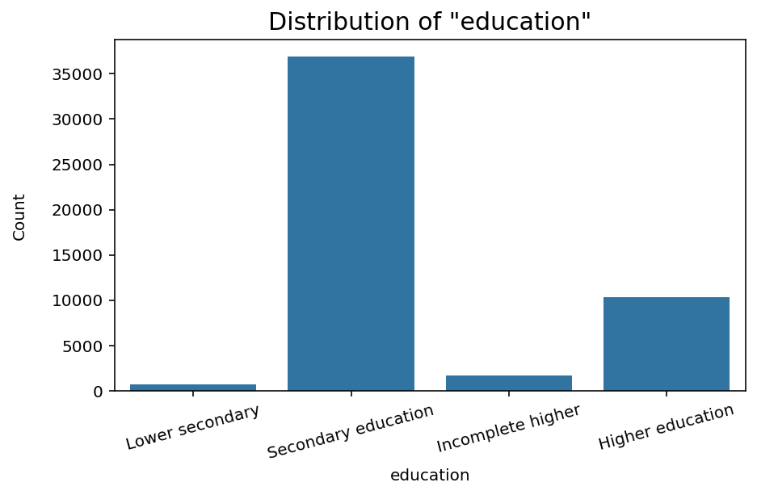

```python
plt.figure(figsize=(7,4))
sns.countplot(data=df, x='education', color='C0') #No need to specify the order as it was set earlier
plt.title('Distribution of "education"', fontsize=15)
plt.ylabel('Count', labelpad=15)
plt.xticks(rotation=15)
plt.show()
```

1. Borrowers with a higher education are less likely to make late payments, because, on average, they have higher incomes;
2. Older borrowers are less likely to make late payments, because they have higher incomes (unless they are retired) and they probably asked for a lower loan amount, which is easier to pay back.

I will investigate these assumptions in the bivariate exploration.

Finally, let's check the univariate distribution of "income" and "loan_amount".  
As mentioned before, the maximum value for income is 117mln dollars, which is probably an outlier. Let's check the deciles for "income".

```python
for i in range(0,101,10):
  print(i,"th percentile: ", np.percentile(df['income'], i))
```

```
0 th percentile:  25.65
10 th percentile:  81.0
20 th percentile:  99.0
30 th percentile:  112.5
40 th percentile:  135.0
50 th percentile:  144.0
60 th percentile:  157.5
70 th percentile:  180.0
80 th percentile:  225.0
90 th percentile:  270.0
100 th percentile:  117000.0
```

There are clearly some outliers. Let's further investigate them.

```python
df.nlargest(10, 'income')
```

| id | late_payments | gender | own_car | own_house | n_children | income | loan_amount | education | age | n_adults |
| --- | --- | --- | --- | --- | --- | --- | --- | --- | --- | --- |
| 114967 | 1 | Female | No | Yes | 1 | 117000.0 | 562.491 | Secondary education | 35 | 2 |
| 196091 | 0 | Female | No | Yes | 1 | 3375.0 | 900.000 | Higher education | 38 | 2 |
| 387126 | 1 | Female | Yes | Yes | 1 | 3150.0 | 900.000 | Higher education | 37 | 2 |
| 148308 | 1 | Male | Yes | Yes | 1 | 1890.0 | 781.920 | Higher education | 36 | 2 |
| 388040 | 1 | Male | Yes | Yes | 0 | 1890.0 | 900.000 | Higher education | 45 | 2 |
| 261411 | 0 | Female | Yes | No | 2 | 1800.0 | 738.171 | Secondary education | 38 | 2 |
| 330110 | 0 | Female | No | Yes | 0 | 1800.0 | 1006.920 | Secondary education | 57 | 2 |
| 127883 | 0 | Female | Yes | No | 0 | 1800.0 | 1350.000 | Higher education | 41 | 2 |
| 336135 | 0 | Male | Yes | No | 0 | 1575.0 | 269.550 | Secondary education | 24 | 1 |
| 294352 | 1 | Female | No | Yes | 0 | 1575.0 | 553.806 | Secondary education | 51 | 2 |

I will remove the highest value of income as it is clearly an outlier and would affect the quality of the results and visuals.

```python
df.drop(df.nlargest(1, 'income').index, inplace = True)
```

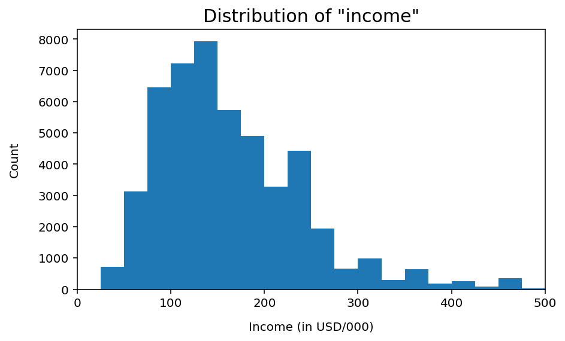

```python
plt.figure(figsize=(7,4))
bins = np.arange(0, df['income'].max()+25, 25)
plt.hist(data = df, x = 'income', bins=bins)
plt.title('Distribution of "income"', fontsize=15)
plt.ylabel('Count', labelpad=15)
plt.xlabel('Income (in USD/000)', labelpad=10)
plt.xlim(0, 500)
plt.show()
```

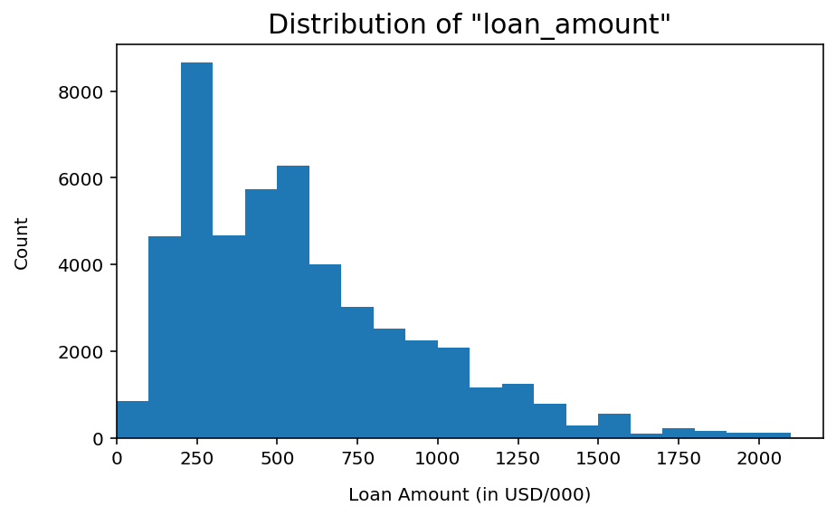

```python
plt.figure(figsize=(7,4))
bins = np.arange(0, df['loan_amount'].max()+100, 100)
plt.hist(data = df, x = 'loan_amount', bins=bins)
plt.title('Distribution of "loan_amount"', fontsize=15)
plt.ylabel('Count', labelpad=15)
plt.xlabel('Loan Amount (in USD/000)', labelpad=10)
plt.xlim(0, 2200)
plt.show()
```

Both the distributions of "income" and "loan_amount" are right skewed.

I am expecting:

- Higher incomes to be associated with more punctuality in making the payments;
- Higher loan amounts to be associated with more delays in making the payments, because it is harder to pay them back.

### Quick Summary (Univariate Exploration)

##### Target variable:

Originally the distribution of the target variable ("late_payments") was highly imbalanced as there were way more values falling under the category "Timely Payment" compared to "Late Payment". That is why I applied random undersampling and obtained a more balanced distribution. However, no invalid or unusual values were included.

##### Other features:

I found outliers in the variables "income" and "n_children". In the first case I decided to drop the outlier, as it was only a single observation; in the second case I decided to replace the outliers with the most similar value to those that I dropped.

## Bivariate Exploration

In this section I will investigate the relationships between pairs of variables in the dataset, by focusing in particular on the relationship of my target variable "late_payments" with all the other features.

Let's start by checking the relationship between "late_payments" and "gender", "own_car" and "own_house". Since these are categorical variables I will use clustered bar charts to investigate their relationship.

Earlier I applied random undersampling and obtained a more balanced distribution for the target variable "late_payments". However, as noticed in the univariate exploration, the categories of all the other features are quite imbalanced as well. Let's consider the example below.

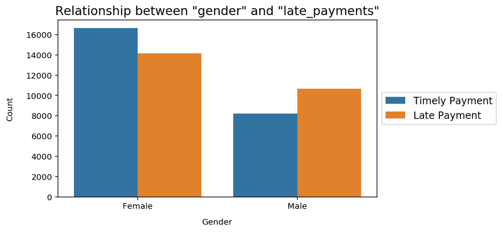

```python
plt.figure(figsize=(7,4))
my_order = df['gender'].value_counts().index
sns.countplot(data=df, x='gender', hue='late_payments', order=my_order);
plt.title('Relationship between "gender" and "late_payments"', fontsize=15)
plt.ylabel('Count', labelpad=15)
plt.xlabel('Gender', labelpad=10)
plt.legend(['Timely Payment', 'Late Payment'], fontsize=12, loc = 6, bbox_to_anchor = (1.0, 0.5))
plt.show()
```

This plot clearly shows that the majority of borrowers are females and that females are more punctual than males. However, due to the different number of observations between the two categories of gender, it is hard to make a comparison between them and identify, within each category, the percentage of borrowers who are punctual in making the payments and those who are not.

To address this issue and be able to make comparison across categories of a single feature, I will represent my target variable "late_payments" as percentage of the total of each category of the feature considered (e.g. in case of "gender", as percentage of the total for male and female).

```python
#Define a function to create bar charts showing the percentages of late payments for each category of a variable
def make_bar_percentage(column, x_size):
    pd.crosstab(df[column], df['late_payments'], normalize='index').plot(figsize=(x_size, 4.5), kind='bar', width=0.8) #Plot

    #Modify plot title, labels, legend
    plt.title('Relationship between "'+column+'" and "late_payments"', fontsize=13, y=1.02) #Set title
    plt.ylabel('Percentage by category', labelpad=8, fontsize=12) #Set y axis text, position and size
    plt.yticks((np.arange(0, 1.1, 0.1)), fontsize=9) #Set y ticks size
    plt.gca().yaxis.set_major_formatter(PercentFormatter(1)) #Set percentage format to y axis
    plt.xlabel(column, labelpad=8, fontsize=10) #Set x axis position and size
    plt.xticks(rotation=0, ha='center', fontsize=11) #Set x ticks position and size
    plt.legend(['Timely', 'Late'], title='Payments', title_fontsize= 13, fontsize=12,
               loc=6, bbox_to_anchor=(1.0, 0.5)) #Set legend and movoe it to the right

    #Add labels on top of bars
    x_position=-0.19 #Set initial position
    table = pd.crosstab(df[column], df['late_payments'], normalize='index') #Get crosstab with percentages of total by row
    for i in range(table.shape[0]): #Loop though each row of the table
        for j in range(table.shape[1]): #Loop though each column of the table
            value=table.values[i,j] #Store each value
            plt.text(x_position, value+0.04, '{:.2f}%'.format(value*100), ha='center', va='top') #Print label in percentage
            x_position=x_position+0.41 #Increment position for the adjacent label
        x_position=x_position+0.18 #Increment position for the next category

    plt.show()
```

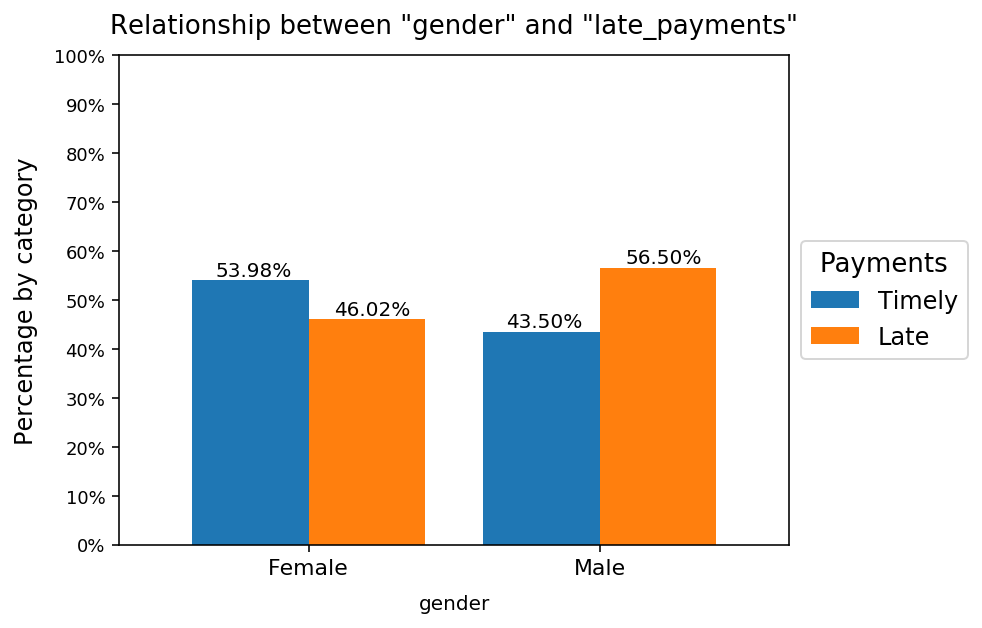

```python
make_bar_percentage('gender', 6)
```

Now I can clearly affirm that males are more likely to make a late payment than females by 10%.

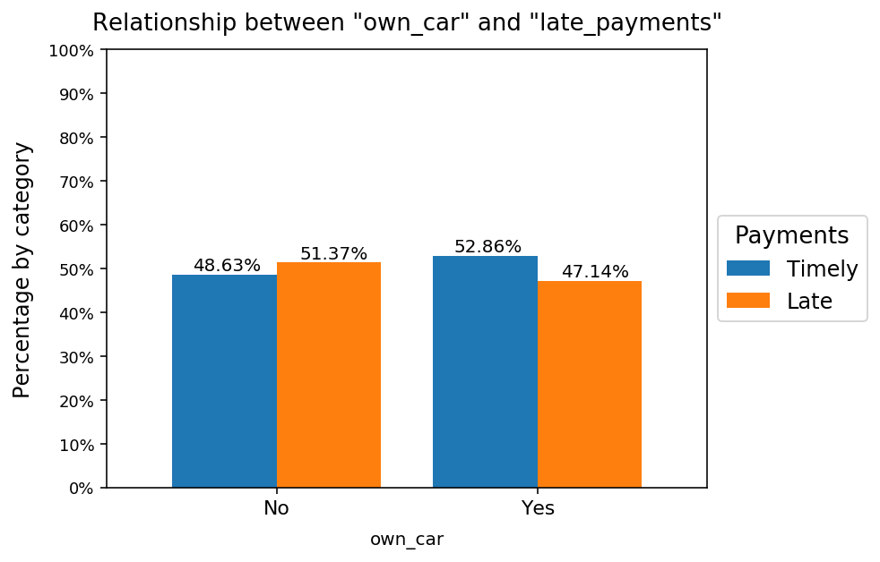

```python
make_bar_percentage('own_car', 6)
```

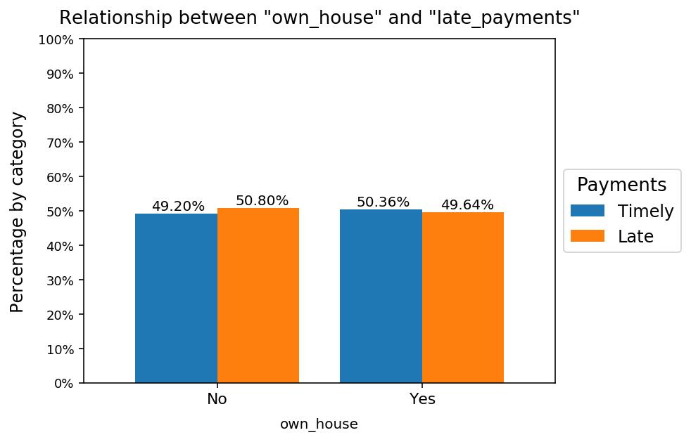

```python
make_bar_percentage('own_house', 6)
```

As shown in the three above charts, "own_car" and "own_house" do not seem to have a relevant effect on the punctuality of payments, whereas "gender" does: females are generally more punctual than males.

Let's now check "n_adults" and "n_children". I am expecting that:

1. Borrowers whose number of adult family members is two are more likely to make timely payments compared to borrowers whose number of adult family members is one, due to another person contributing to the family income;
2. The higher the number of children, the harder it is to make timely payments, due to more family expenses.

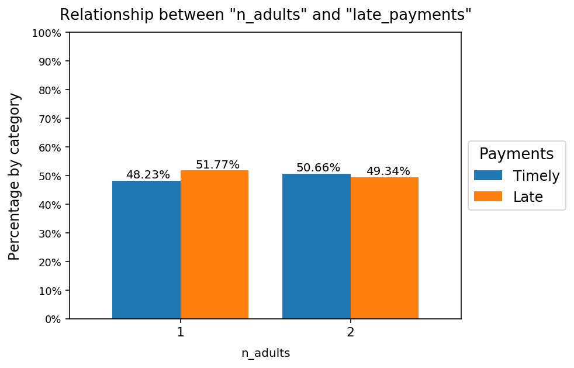

```python
make_bar_percentage('n_adults', 6)
```

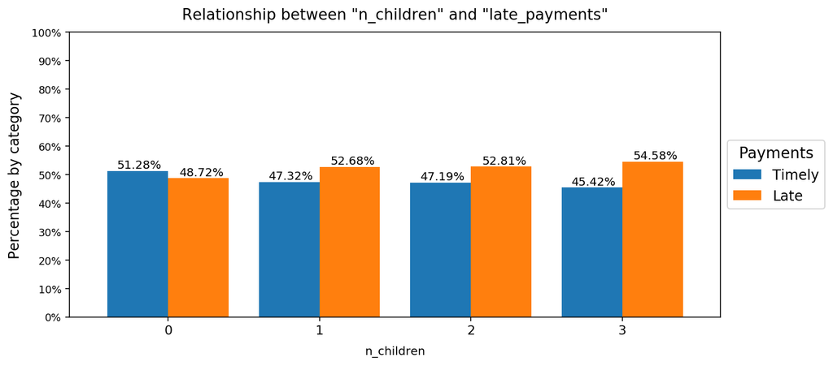

```python
make_bar_percentage('n_children', 10)
```

The data shows that my assumptions were correct:

1. Borrowers with two adults family members are more punctual than borrowers with only one, although the difference is extremely small;
2. As their number of children increases, borrowers are less likely to make timely payments.

Let's now check the relationship between "education" and "late_payments".

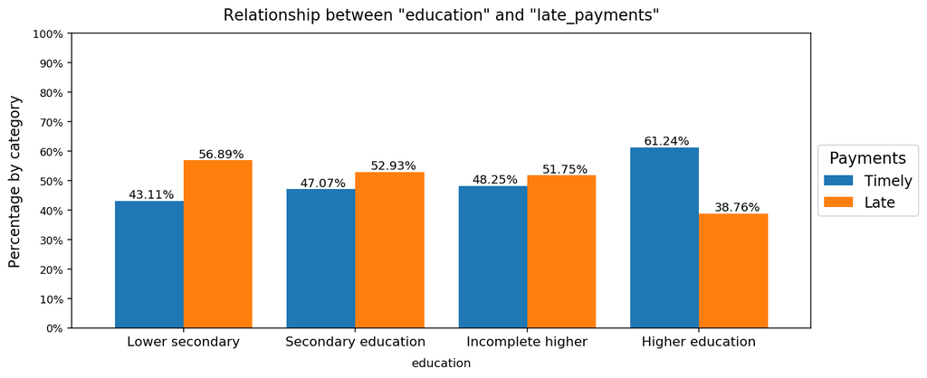

```python
make_bar_percentage('education', 11)
```

The above chart shows that education has a large effect on "late_payments": as their level of education increases, borrowers are more likely to be punctual in making the payments. Between the lowest and the highest level of education, the percentage difference is about 18%. I believe that this effect is related to the fact that a higher level of education is generally associated with a higher income, and a higher income leads to a smaller probability to make a late payment.

To verify this assumption, I will have to investigate the relationship between "income" and "late_payments" and between "education" and "income".

Let's finally check the relationship of "age", "income" and "loan_amount" with "late_payments". Since my target variable is categorical and the others are quantitative I will use box plots to investigate their relationships.

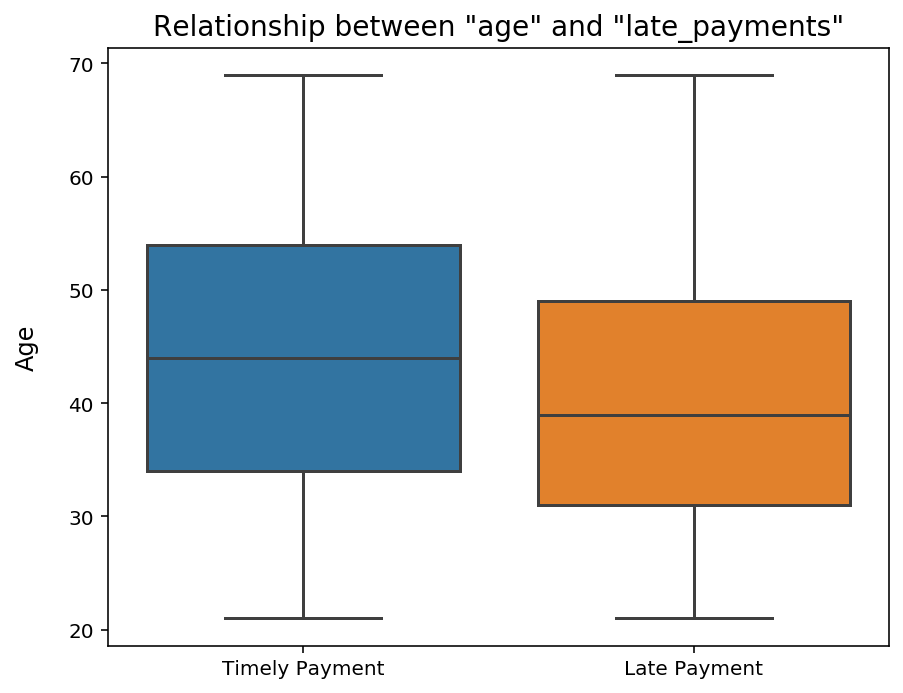

```python
plt.figure(figsize=(7, 5.5))
ax=sns.boxplot(data=df, x='late_payments', y='age')
ax.set_xticklabels(['Timely Payment', 'Late Payment'])
plt.title('Relationship between "age" and "late_payments"', fontsize=14)
plt.ylabel('Age', labelpad=15, fontsize=12)
plt.xlabel('')
plt.show()
```

The chart shows that borrowers who make late payments tend to be slightly younger than borrowers who make timely payments. However, the two distributions have significant overlap, so the overall effect of age is limited.

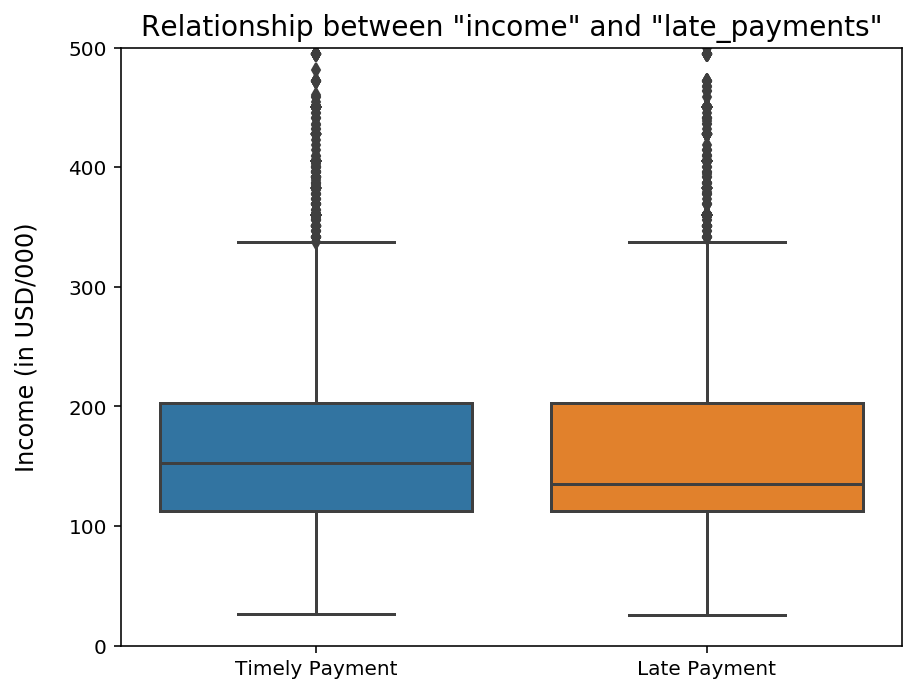

```python
plt.figure(figsize=(7, 5.5))
ax=sns.boxplot(data=df, x='late_payments', y='income')
ax.set_xticklabels(['Timely Payment', 'Late Payment'])
plt.title('Relationship between "income" and "late_payments"', fontsize=14)
plt.ylabel('Income (in USD/000)', labelpad=15, fontsize=12)
plt.xlabel('')
plt.ylim(0,500)
plt.show()
```

The result found here is extremely surprising: the two distributions are overlapping, although the median of the group on the right is slightly lower. Therefore income does not seem to have a relevant effect on the punctuality of payments. My earlier assumption about a higher level education leading to less late payments due to a higher income seems to be incorrect.

Let's investigate the relationship between education and income.

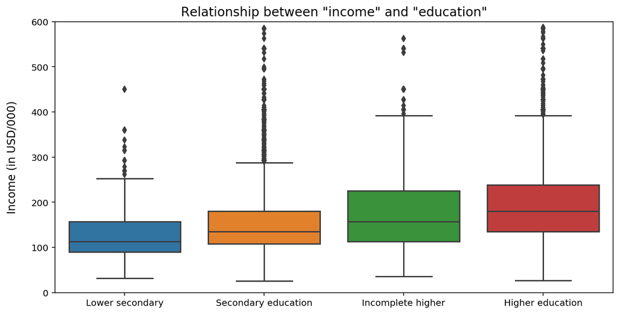

```python
plt.figure(figsize=(11, 5.5))
ax=sns.boxplot(data=df, x='education', y='income')
plt.title('Relationship between "income" and "education"', fontsize=14)
plt.ylabel('Income (in USD/000)', labelpad=15, fontsize=12)
plt.xlabel('')
plt.ylim(0,600)
plt.show()
```

There is clearly a positive relationship between the level of education and the income, but this has no effect on the punctuality of payments. It seems that what is actually affecting the punctuality of payments is level of education itself, regardless of the income.

Finally, let's plot the relationship between "loan_amount" and "late_payments".

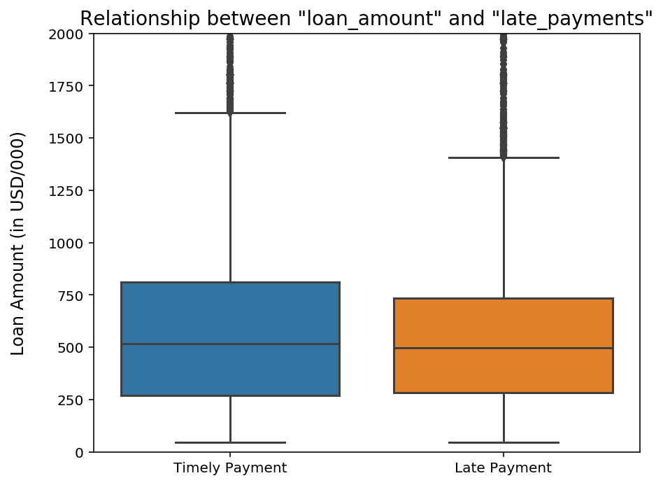

```python
plt.figure(figsize=(7, 5.5))
ax=sns.boxplot(data=df, x='late_payments' , y='loan_amount')
ax.set_xticklabels(['Timely Payment', 'Late Payment'])
plt.title('Relationship between "loan_amount" and "late_payments"', fontsize=14)
plt.ylabel('Loan Amount (in USD/000)', labelpad=15, fontsize=12)
plt.xlabel('')
plt.ylim(0,2000)
plt.show()
```

The two distributions are overlapping, thus the total amount of the loan does not seem to affect the probability of making a late payment either.

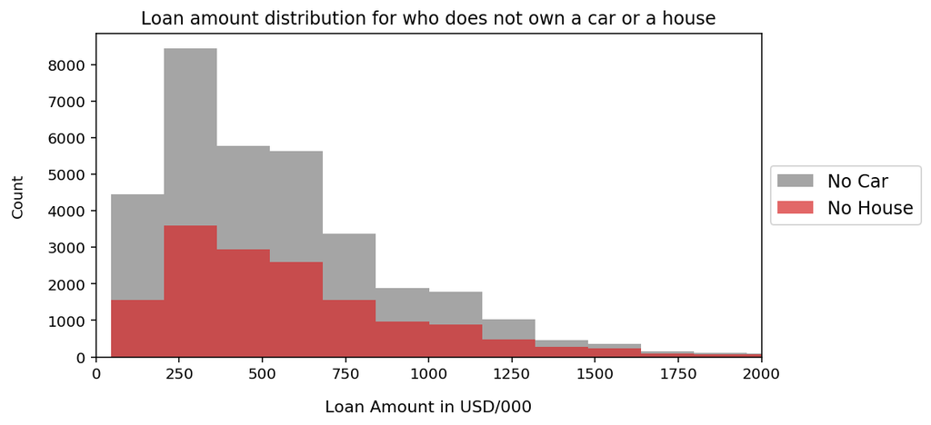

```python
#Create the two dataframes
df_nocar=df.loc[df['own_car']=='No']
df_nohouse=df.loc[df['own_house']=='No']
#Create histograms
plt.figure(figsize=(8,4))
plt.hist(data=df_nocar, x='loan_amount', bins=25, label='No Car', alpha=0.7, color='C7');
plt.hist(data=df_nohouse, x='loan_amount', bins=25, label='No House', alpha=0.7, color='C3');
#Add legend, title, labels
plt.legend(fontsize=12, loc=6, bbox_to_anchor=(1.0, 0.5))
plt.title('Loan amount distribution for who does not own a car or a house', fontsize=12)
plt.ylabel('Count', labelpad=15, fontsize=10)
plt.xlabel('Loan Amount in USD/000', labelpad=12, fontsize=11)
plt.xlim(0,2000)
plt.show()
```

```python
no_car=df.loc[df['own_car']=='No']['loan_amount'].mean()
no_house=df.loc[df['own_house']=='No']['loan_amount'].mean()
print('The average loan amount for borrowers who do not own a car is', int(no_car),'USD/000')
print('The average loan amount for borrowers who do not own a house is', int(no_house),'USD/000')
```

```
The average loan amount for borrowers who do not own a car is 551 USD/000
The average loan amount for borrowers who do not own a house is 593 USD/000
```

The two distributions are very similar, so there isn't a large difference in the loan amount requested between borrowers who do not own a car and those who do not own a house; the average loan amount is just slightly higher for the latter group.

### Quick Summary (Bivariate Exploration)

The most important relationships I found between the target variable ("late_payments") and the other features are the following:

1. Education → As their level of education increases, borrowers tend to make less late payments;
2. Gender → Females are more punctual than males;
3. Number of children → As the number of children increases, borrowers tend to make more late payments;
4. Age → Late payments tend to be made more by younger than older people.

I investigated the relationship between education and income and it turns out that, as could be expected, a higher level of education is associated with a higher income. However, surprisingly, I found is that a higher income is not associated with more punctuality of payments.

## Exploratory Data Analysis - Conclusions

In the bivariate exploration I discovered something surprising:

- There is a positive relationship between level of education and income, as predictable;
- There is a negative relationship between the level of education of the borrowers and their probability of making a late payment;
- However, there is almost no relationship between income and the probability of making a late payment.

Thus it seems that borrowers with a higher level of education tend to pay on time not because they earn more money, but because education is affecting their behavior directly. My hypothesis is that borrowers with higher level of education tend to be more precise and organized, therefore they pay more attention to the due dates of payments.

Let's plot these three variables together in a multivariate chart.

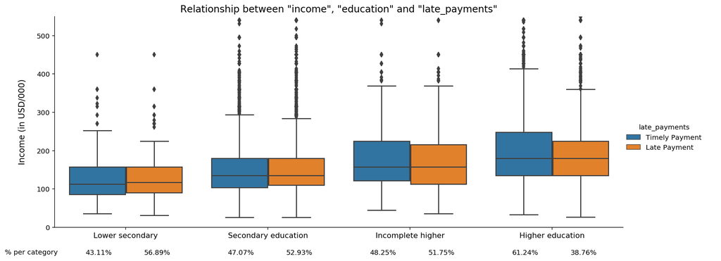

```python
ax = sns.catplot(data=df, x='education', y='income', hue='late_payments', kind='box', height=5, aspect=2.5)

ax._legend.set_bbox_to_anchor([1.05, 0.5])  #Change legend position
for t, l in zip(ax._legend.texts, ['Timely Payment', 'Late Payment']): #Replace legend labels
    t.set_text(l)
ax.axes[0,0].set_xlabel('') #Remove xlabel

plt.title('Relationship between "income", "education" and "late_payments"', fontsize=14)
plt.ylabel('Income (in USD/000)', labelpad=15, fontsize=12)
plt.ylim(0,550)
plt.xticks(fontsize=11)

#Add percentage of borrowers per category below each boxplot
x_position=-0.19 #Set initial position
table = pd.crosstab(df['education'], df['late_payments'], normalize='index') #Get crosstab with percentages of total by row
for i in range(table.shape[0]): #Loop though each row of the table
    for j in range(table.shape[1]): #Loop though each column of the table
        value=table.values[i,j]
        plt.text(x_position, -58, '{:.2f}%'.format(value*100), ha='center', va='top') #Print label in percentage
        x_position=x_position+0.41 #Increment position for the adjacent label
    x_position=x_position+0.18 #Increment position for the next category

plt.text(-0.85, -70, '% per category'); #Add text on the bottom left

plt.show()
```

The multivariate chart above shows what I already discovered in the previous phase: as the level of education increases the income increases too, but the distributions of borrowers who paid on time and those who paid late are overlapping in each level of education, showing that income does not have a relevant effect on the punctuality of payments. However, education does: as the level of education increases, the percentage of borrowers making a late payment decreases.

Let's conclude by showing the relationship of "late_payments" with "education" and "gender" together, since these are the two variables with the highest impact on the punctuality of payment.

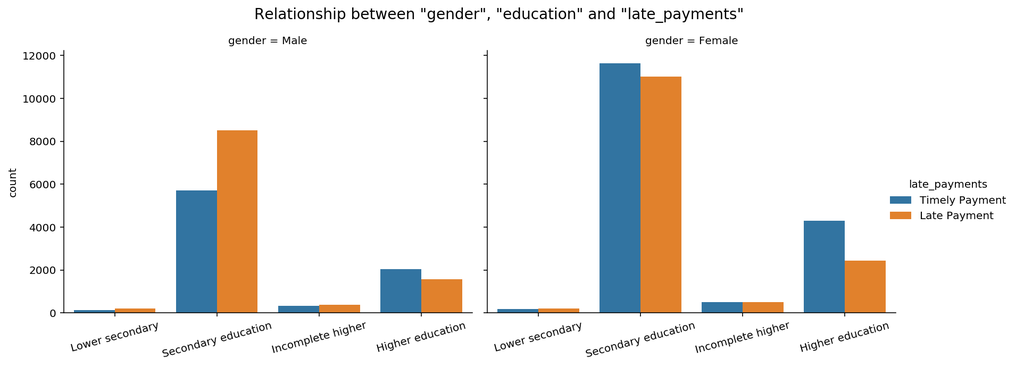

```python
ax = sns.catplot(data=df, x='education', hue='late_payments', col='gender', kind='count', height=4.35, aspect=1.35)

ax._legend.set_bbox_to_anchor([1.03, 0.5])  #Change legend position
ax.set_xticklabels(rotation=15)
ax.axes[0,0].set_xlabel('') #Remove xlabel in left chart
ax.axes[0,1].set_xlabel('') #Remove xlabel in right chart
for t, l in zip(ax._legend.texts, ['Timely Payment', 'Late Payment']): #Replace legend labels
    t.set_text(l)

plt.suptitle('Relationship between "gender", "education" and "late_payments"', fontsize=14, y=1.05)
plt.show()
```

As noticed during bivariate exploration:

- Male borrowers are more likely to make late payments than females;
- Borrowers with a lower level of education are more likely to make late payments than borrowers with a higher level of education.

It is interesting to note that even for low level of educations female borrowers tend to make more payments on time rather than late.

Therefore, according to this analysis the best clients for banks are females with a high level of education; on the contrary, they should take more precautions for men with a low level of education.